# imput na

Grupo 5

2025-10-12

Los valores faltantes surgen cuando una observación carece de información registrada en una determinada variable. Su correcta gestión es fundamental, ya que eliminarlos indiscriminadamente puede reducir de manera significativa el tamaño del conjunto de datos, mientras que imputarlos de forma inadecuada puede introducir sesgos y distorsionar los resultados del análisis.

Para abordar este problema existen diversas estrategias. Entre las más comunes se encuentran:

- **Eliminación** de filas o columnas con un número elevado de valores faltantes.
- **Imputación simple**, que consiste en reemplazar los valores ausentes con medidas como la media, mediana o moda.
- **Imputación avanzada**, donde se emplean métodos más sofisticados como K-Nearest Neighbors (KNN) o modelos predictivos para estimar los valores faltantes de manera más precisa.

# Exploración de los NA

Realizamos un test de Little para comprobar si los NA de nuestros datos son MCAR (aleatorios) o si por el contrario siguen algún patron.

El test de Little se utiliza para evaluar si los datos faltantes en un conjunto de datos siguen el mecanismo **MCAR** (*Missing Completely At Random*).

### Hipótesis

- **Hipótesis nula ($H_0$):**  
  Los valores faltantes son completamente aleatorios (MCAR).  
  Es decir, la probabilidad de que un valor esté ausente no depende de los datos observados ni de los no observados.
- **Hipótesis alternativa ($H_1$):**  
  Los valores faltantes no son completamente aleatorios.  
  En este caso, el patrón de datos ausentes depende de los valores observados y/o de los no observados.

```r
naniar::mcar_test(data)
```

```
## # A tibble: 1 × 4
##   statistic     df p.value missing.patterns
##       <dbl>  <dbl>   <dbl>            <int>
## 1   168204. 168039   0.387             9809
```

Dado que el pvalor es ampliamente superior a 0.05, aceptamos la hipótesis nula: no hay evidencia estadística para sospechar que los valores faltantes de nuestra base de datos no son fruto de la aleatoriedad.

Vamos a visualizar la distribución de nuestros NA para las diferentes variables.

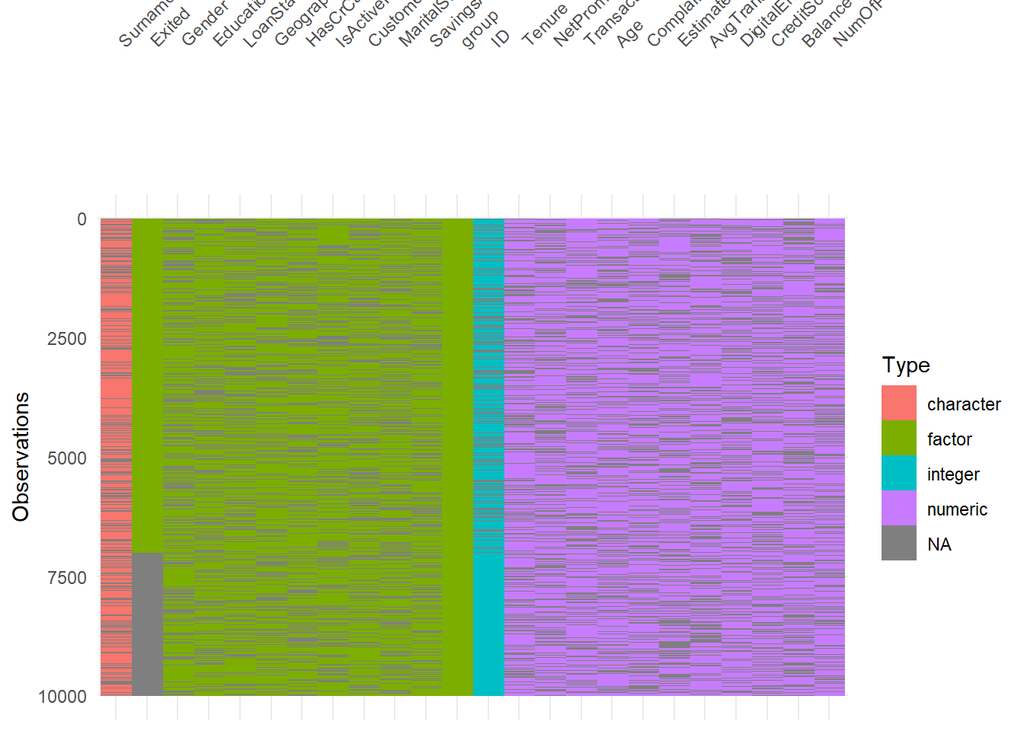

```r
vis_dat(data)
```

Tampoco se observa ningún patrón fuera de los generados para este problema concreto del caso del banco (ID, group, Exited).

Cantidad de NA por variable:

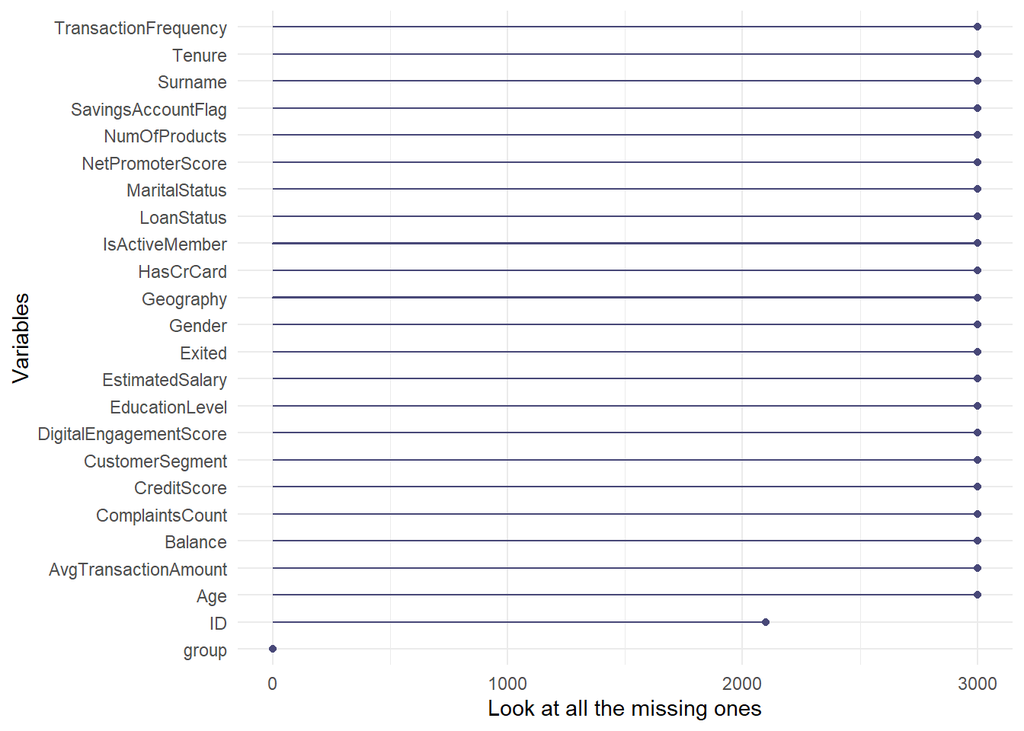

```r
gg_miss_var(data) + labs(y = "Look at all the missing ones")
```

Ya habíamos visto que en todas las variables la proporción de NA es del 30%. Esto no pasa para ID, dado que los datos test no tienen valores faltantes ni para group, variable que hemos generado nosotros para indicar si una observación es grupo train/test.

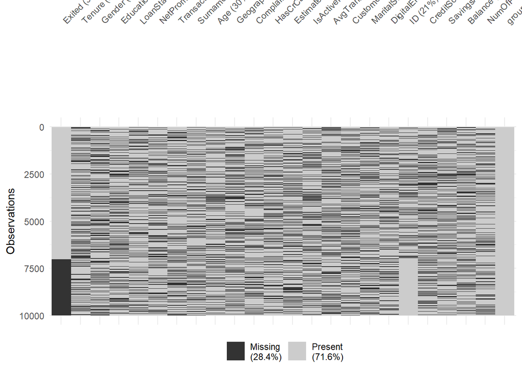

```r
vis_miss(data);
```

Con este gràfico estamos recalcando la información conocida por estudios diferentes y por el gràdico anterior

```r
pct_miss_case(data)
```

```
## [1] 100
```

# Imputación de los NA

La imputación básica consiste en reemplazar los valores faltantes por estimaciones simples basadas en los datos disponibles, sin emplear modelos complejos. Entre los métodos más frecuentes se encuentran:

- **Reemplazo por la media o mediana:** posibilidad para las variables numéricas.
- **Reemplazo por la moda:** aplicable a variables categóricas.
- **Constante o valor fijo:** se puede asignar un valor específico que tenga sentido según el contexto.

Estos métodos son fáciles de aplicar y permiten mantener el tamaño original del dataset, aunque no capturan relaciones más complejas entre las variables. Son una primera aproximación al manejo de datos faltantes, y en muchos casos se utilizan como paso previo antes de aplicar técnicas de imputación más avanzadas.

## Imputación por media y mediana

Como hemos comentado anteriormente la imputación de la media o mediana es adecuada para las variables numericas. Aplicaremos estos métodos a dichas variables y comprobaremos si la distribución posterior se ajusta bien a la de los datos con NA.

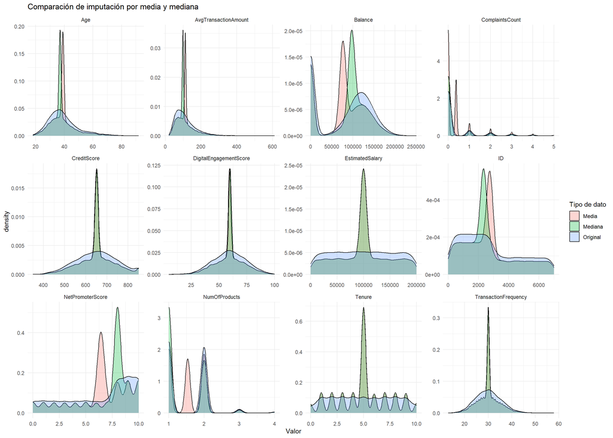

```r
data_mean <- data %>%
  mutate(across(where(is.numeric),
                ~ Hmisc::impute(., fun = mean),
                .names = "imputed_mean_{.col}"))

data_median <- data %>%
  mutate(across(where(is.numeric),
                ~ Hmisc::impute(., fun = median),
                .names = "imputed_median_{.col}"))

data_all <- data %>%
  bind_cols(
    select(data_mean, starts_with("imputed_mean_")),
    select(data_median, starts_with("imputed_median_"))
  )


df_long_all <- data_all %>%
  select(where(is.numeric)) %>%
  pivot_longer(
    cols = everything(),
    names_to = "VariableCompleta",
    values_to = "Valor"
  ) %>%
  mutate(
    Tipo = case_when(
      grepl("^imputed_mean_", VariableCompleta) ~ "Media",
      grepl("^imputed_median_", VariableCompleta) ~ "Mediana",
      TRUE ~ "Original"
    ),
    Variable = gsub("^(imputed_mean_|imputed_median_)", "", VariableCompleta)
  )
ggplot(df_long_all, aes(x = Valor, fill = Tipo)) +
  geom_density(alpha = 0.3) +
  facet_wrap(~ Variable, scales = "free") +
  theme_minimal() +
  labs(title = "Comparación de imputación por media y mediana",
       fill = "Tipo de dato")
```

Observamos como ni la media ni la mediana parecen métodos fiables para la imputación de ninguna de las numéricas, puesto que la densidad de ninguno de las dos metodologías se ajusta bien a la densidad orignal de los datos sin NA.

## Moda

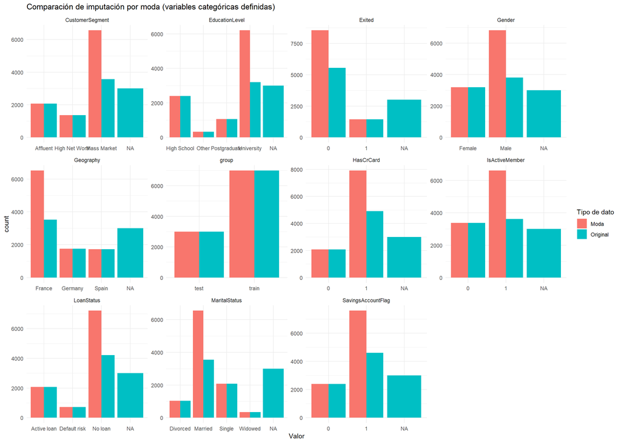

```r
library(dplyr)
library(tidyr)
library(ggplot2)

get_mode <- function(x) {
  ux <- na.omit(unique(x))
  ux[which.max(tabulate(match(x, ux)))]
}

data_mode <- data %>%
  mutate(across(all_of(varCat),
                ~ ifelse(is.na(.), as.character(get_mode(.)), as.character(.)),
                .names = "imputed_mode_{.col}"))

data_all <- data %>%
  select(all_of(varCat)) %>%
  mutate(across(everything(), as.character)) %>%   # <-- forzamos a character para evitar conflictos
  bind_cols(
    data_mode %>%
      select(starts_with("imputed_mode_")) %>%
      mutate(across(everything(), as.character))   # <-- igual aquí
  )

df_long_all <- data_all %>%
  pivot_longer(
    cols = everything(),
    names_to = "VariableCompleta",
    values_to = "Valor"
  ) %>%
  mutate(
    Tipo = case_when(
      grepl("^imputed_mode_", VariableCompleta) ~ "Moda",
      TRUE ~ "Original"
    ),
    Variable = gsub("^(imputed_mode_)", "", VariableCompleta)
  )

ggplot(df_long_all, aes(x = Valor, fill = Tipo)) +
  geom_bar(position = "dodge") +
  facet_wrap(~ Variable, scales = "free") +
  theme_minimal() +
  labs(title = "Comparación de imputación por moda (variables categóricas definidas)",
       fill = "Tipo de dato")
```

La imputación por moda no es el mejor metodo de imputación para las variables categoricas bien porque distorsiona severamente la distribución real de los datos, creando un sesgo excesivo hacia las categorías dominantes y eliminando la variabilidad natural del dataset original.

## Media con variable target

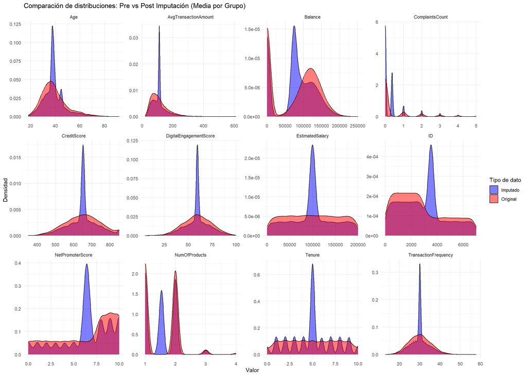

```r
data_imputado <- data

var_numericas <- names(data_imputado)[sapply(data_imputado, is.numeric)]
var_numericas <- var_numericas[var_numericas != "Exited"]

data_imputado <- data_imputado %>%
  group_by(Exited) %>%
  mutate(across(all_of(var_numericas),
                ~ {
                  media_grupo <- mean(., na.rm = TRUE)
                  ifelse(is.na(.), media_grupo, .)
                })) %>%
  ungroup()

df_original <- data %>%
  select(where(is.numeric)) %>%
  pivot_longer(
    cols = everything(),
    names_to = "Variable",
    values_to = "Valor"
  ) %>%
  mutate(Tipo = "Original")

df_imputado <- data_imputado %>%
  select(where(is.numeric)) %>%
  pivot_longer(
    cols = everything(),
    names_to = "Variable",
    values_to = "Valor"
  ) %>%
  mutate(Tipo = "Imputado")

df_comparacion <- bind_rows(df_original, df_imputado)

ggplot(df_comparacion, aes(x = Valor, fill = Tipo)) +
  geom_density(alpha = 0.5) +
  facet_wrap(~ Variable, scales = "free") +
  theme_minimal() +
  labs(title = "Comparación de distribuciones: Pre vs Post Imputación (Media por Grupo)",
       x = "Valor",
       y = "Densidad",
       fill = "Tipo de dato") +
  scale_fill_manual(values = c("Original" = "red", "Imputado" = "blue"))
```

Vemos que la imputación de media con una variable target (en este caso exited) tampoco representa una opción fiable de cara a la imputación de datos faltantes, dado que no respeta la densidad original para ninguna de las variables numéricas

## Mi method

El método de imputación múltiple es una técnica estadística avanzada para manejar valores faltantes en un conjunto de datos.

A diferencia de las imputaciones simples, que reemplazan cada valor faltante por un único estimador como la media o la moda, MI genera varios datasets completos donde los valores faltantes son reemplazados por estimaciones diferentes basadas en modelos estadísticos que capturan la incertidumbre de los datos ausentes.

```r
data_mi<-data
library(dplyr)
library(mi)

data_mi <- data_mi %>%
  mutate(across(where(is.character), as.factor))

colSums(is.na(data_mi))

data_mi <- data_mi %>% select(where(~ any(is.na(.))))

mi_data <- mi(data_mi, seed = 335, m = 3, maxit = 5)

summary(mi_data)

plot(mi_data)
par(ask = FALSE)
```

Por complicaciones técnicas al implementar el método MI, en este trabajo se optó por utilizar el paquete MICE, que permite realizar imputación múltiple de manera más estable y flexible sobre datasets con valores faltantes.

## KNN mixto

A continuación probaremos el método KNN para la imputación de NA para las variables categóricas:

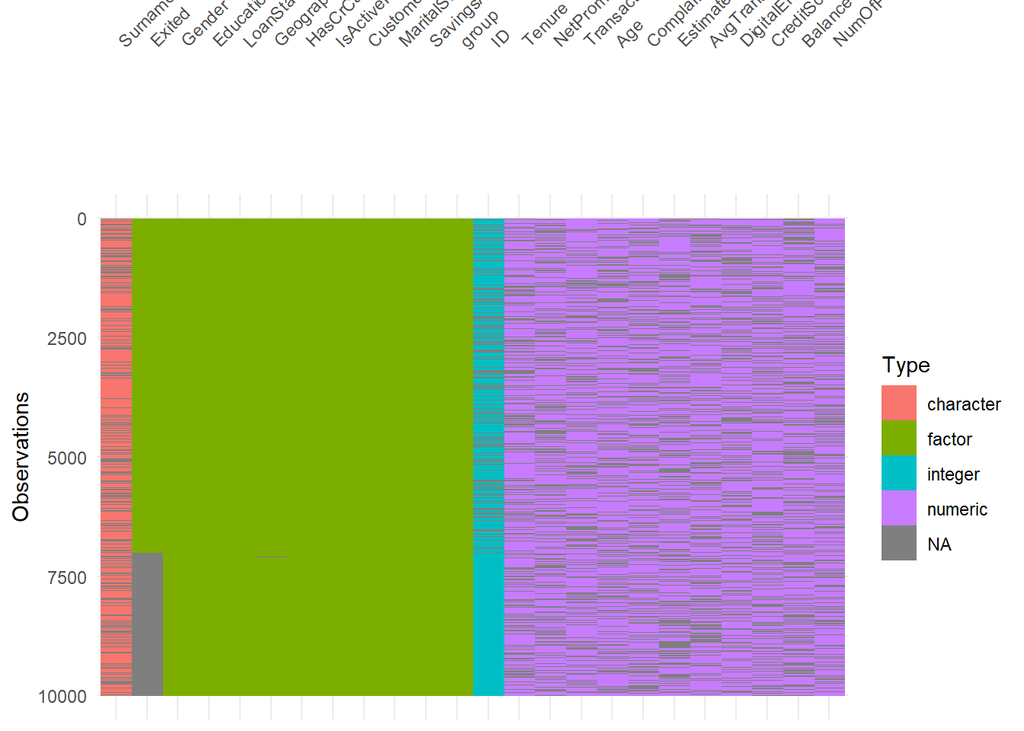

```r
data4knn<-data
library(cluster)
k <- 5
variables_excluir <- c("ID", "Surname", "Exited")

vars_cat <- names(data4knn)[sapply(data4knn, function(x) is.character(x) | is.factor(x))]
vars_imputar <- setdiff(vars_cat, variables_excluir)

  data4knn_final <- data4knn
  vars_dist <- setdiff(names(data4knn), variables_excluir)
  dist_matrix <- as.matrix(daisy(data4knn[vars_dist], metric = "gower"))

  for(var in vars_imputar) {
    na_idx <- which(is.na(data4knn_final[[var]]))

    for(i in na_idx) {
      distancias <- dist_matrix[i, ]
      distancias[i] <- Inf
      vecinos <- order(distancias)[1:k]

      valores <- data4knn_final[[var]][vecinos]
      valores <- valores[!is.na(valores)]

      if(length(valores) > 0) {
        data4knn_final[[var]][i] <- names(sort(table(valores), decreasing = TRUE))[1]
      }
    }
  }


vis_dat(data4knn_final)
```

```r
colSums(is.na(data4knn_final))
```

```
##                 Exited                 Tenure                 Gender
##                   3000                   3000                      3
##         EducationLevel             LoanStatus       NetPromoterScore
##                      3                      0                   3000
##   TransactionFrequency                Surname                    Age
##                   3000                   3000                   3000
##              Geography        ComplaintsCount              HasCrCard
##                      2                   3000                      1
##        EstimatedSalary         IsActiveMember   AvgTransactionAmount
##                   3000                      2                   3000
##        CustomerSegment          MaritalStatus DigitalEngagementScore
##                      0                      0                   3000
##                     ID            CreditScore     SavingsAccountFlag
##                   2100                   3000                      0
##                Balance          NumOfProducts                  group
##                   3000                   3000                      0
```

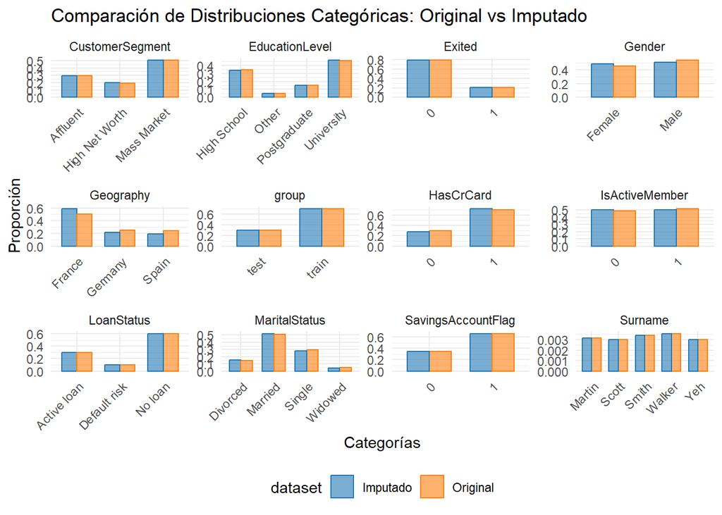

```r
mass_before_after(data, data4knn_final)
```

## 5-NN(2)

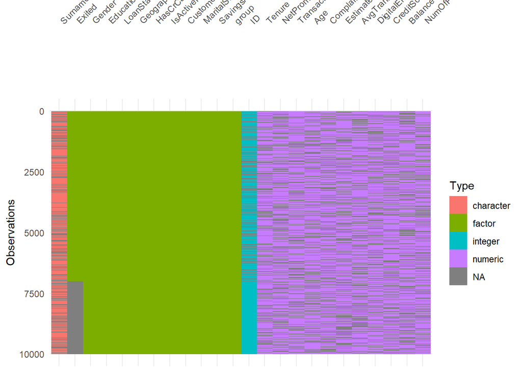

```r
data4knn2<-data4knn_final
library(cluster)
k <- 5
variables_excluir <- c("ID", "Surname", "Exited")

vars_cat <- names(data4knn2)[sapply(data4knn2, function(x) is.character(x) | is.factor(x))]
vars_imputar <- setdiff(vars_cat, variables_excluir)

  data4knn_final2 <- data4knn2
  vars_dist <- setdiff(names(data4knn2), variables_excluir)
  dist_matrix <- as.matrix(daisy(data4knn2[vars_dist], metric = "gower"))

  for(var in vars_imputar) {
    na_idx <- which(is.na(data4knn_final2[[var]]))

    for(i in na_idx) {
      distancias <- dist_matrix[i, ]
      distancias[i] <- Inf
      vecinos <- order(distancias)[1:k]

      valores <- data4knn_final[[var]][vecinos]
      valores <- valores[!is.na(valores)]

      if(length(valores) > 0) {
        data4knn_final2[[var]][i] <- names(sort(table(valores), decreasing = TRUE))[1]
      }
    }
  }


vis_dat(data4knn_final2)
```

```r
colSums(is.na(data4knn_final2))
```

```
##                 Exited                 Tenure                 Gender
##                   3000                   3000                      0
##         EducationLevel             LoanStatus       NetPromoterScore
##                      0                      0                   3000
##   TransactionFrequency                Surname                    Age
##                   3000                   3000                   3000
##              Geography        ComplaintsCount              HasCrCard
##                      0                   3000                      0
##        EstimatedSalary         IsActiveMember   AvgTransactionAmount
##                   3000                      0                   3000
##        CustomerSegment          MaritalStatus DigitalEngagementScore
##                      0                      0                   3000
##                     ID            CreditScore     SavingsAccountFlag
##                   2100                   3000                      0
##                Balance          NumOfProducts                  group
##                   3000                   3000                      0
```

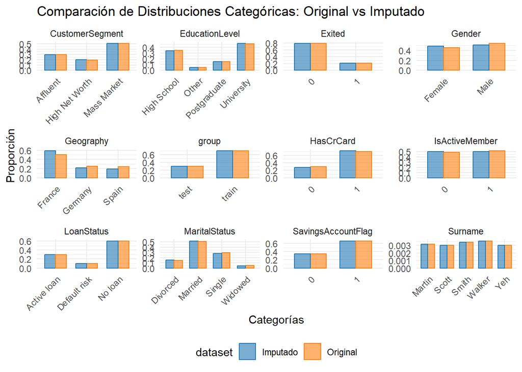

```r
mass_before_after(data, data4knn_final2)
```

Pese a haber solucionado la problemática de los NA, vemos como el ajuste no termina de ser el mejor para la variable Geography, donde hay un desajuste de un 10-15% para la categoría France, que se confunde con las otras dos categorías. Esto podría ser muy perjudicial de cara a una futura modelización, por lo que no podemos validar este método para nuestro caso.

## Multiple chained Equations (MICE)

Para la implementación práctica de la imputación múltiple, se utilizó el paquete MICE. Este método permite generar múltiples datasets completos mediante modelos estadísticos iterativos, manejando tanto variables numéricas como categóricas de manera eficiente.

A continuación, realizamos la imputación de los valores faltantes para las variables numéricas de manera multivariada (utilizando la información de todas las variables numéricas)

```r
library(mice)
library(VIM)  # Para visualizar los datos imputados
datamice <- data

# Identificar tipos de variables
variables_numericas <- names(datamice)[sapply(datamice, is.numeric)]
variables_dicotomicas <- names(datamice)[sapply(datamice, function(x) is.factor(x) && nlevels(x) == 2)]
variables_polinomicas <- names(datamice)[sapply(datamice, function(x) is.factor(x) && nlevels(x) > 2)]

# Variables que no se deben imputar
variables_no_imputar <- c("ID", "Exited")

# Variables a imputar
variables_numericas_imputar <- setdiff(variables_numericas, variables_no_imputar)
variables_dico_imputar <- setdiff(variables_dicotomicas, variables_no_imputar)
variables_poli_imputar <- setdiff(variables_polinomicas, variables_no_imputar)

# Copia de los datos para imputar
datamice_imputado <- datamice

# Crear métodos de imputación
metodos <- make.method(datamice_imputado)

# Asignar métodos de imputación según el tipo de variable
metodos[variables_numericas_imputar] <- "pmm"  # Predictive Mean Matching
metodos[variables_dico_imputar] <- "logreg"    # Regresión logística para dicotómicas
metodos[variables_poli_imputar] <- "polyreg"   # Regresión polinomial para polinómicas

# Configurar la matriz de predictores
pred_mat <- make.predictorMatrix(datamice_imputado)

# Configurar qué variables pueden predecir y ser predecidas
for (var in names(datamice_imputado)) {
  if (var %in% variables_numericas_imputar) {
    # Esta variable numérica puede ser predicha por otras numéricas imputables
    pred_mat[var, variables_numericas_imputar] <- 1
    pred_mat[var, var] <- 0  # No usar la variable misma para predecirse
  }
  # Para excluir ID y Exited de las predictoras y de las imputadas
  if (var %in% variables_no_imputar | !var %in% variables_numericas) {
    pred_mat[var, ] <- 0  # No usar esta variable para predecir otras
    pred_mat[, var] <- 0  # No usar otras variables para predecir esta
  }
}

# Realizar la imputación MICE
imputacion <- mice(
  datamice_imputado,
  m = 5,
  maxit = 10,
  method = metodos,
  predictorMatrix = pred_mat,
  seed = 123,
  printFlag = TRUE
)
```

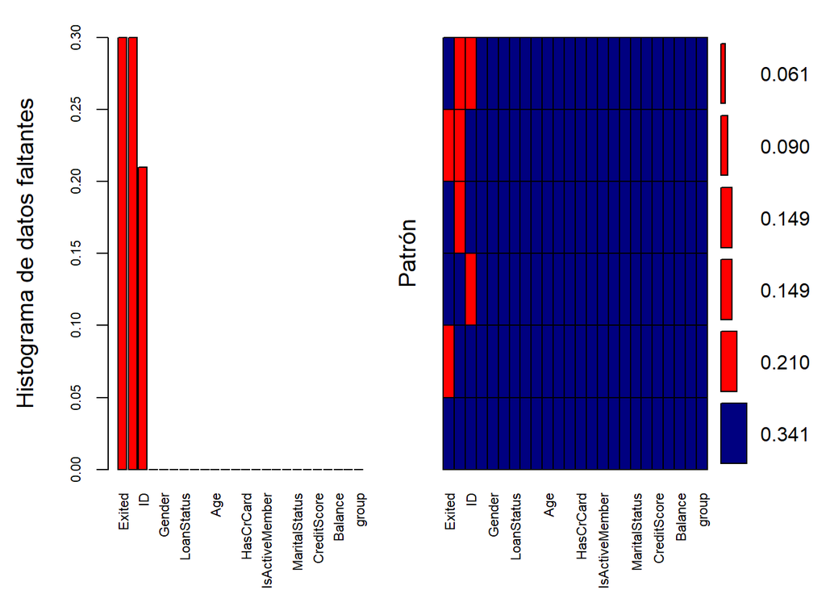

```
##
##  Variables sorted by number of missings:
##                Variable Count
##                  Exited  0.30
##                 Surname  0.30
##                      ID  0.21
##                  Tenure  0.00
##                  Gender  0.00
##          EducationLevel  0.00
##              LoanStatus  0.00
##        NetPromoterScore  0.00
##    TransactionFrequency  0.00
##                     Age  0.00
##               Geography  0.00
##         ComplaintsCount  0.00
##               HasCrCard  0.00
##         EstimatedSalary  0.00
##          IsActiveMember  0.00
##    AvgTransactionAmount  0.00
##         CustomerSegment  0.00
##           MaritalStatus  0.00
##  DigitalEngagementScore  0.00
##             CreditScore  0.00
##      SavingsAccountFlag  0.00
##                 Balance  0.00
##           NumOfProducts  0.00
##                   group  0.00
```

```r
# Completar los datos imputados
datamice_completo <- complete(imputacion, 1)

# Combinar los datos imputados con los originales
datamice_final <- datamice
datamice_final[variables_numericas_imputar] <- datamice_completo[variables_numericas_imputar]
datamice_final[variables_dico_imputar] <- datamice_completo[variables_dico_imputar]
datamice_final[variables_poli_imputar] <- datamice_completo[variables_poli_imputar]

# Visualizar los datos imputados para verificar
aggr_plot <- aggr(datamice_final, col=c('navyblue','red'), numbers=TRUE, sortVars=TRUE, labels=names(datamice_final), cex.axis=.7, gap=3, ylab=c("Histograma de datos faltantes","Patrón"))
```

```r
print(aggr_plot)
```

```
##
##  Missings in variables:
##  Variable Count
##    Exited  3000
##   Surname  3000
##        ID  2100
```

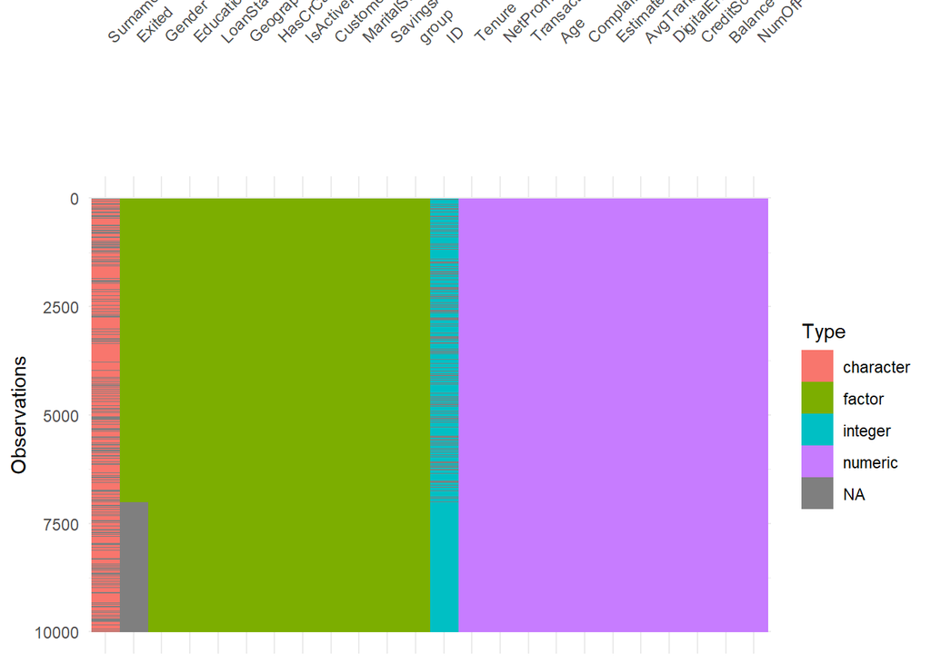

```r
vis_dat(datamice_final)
```

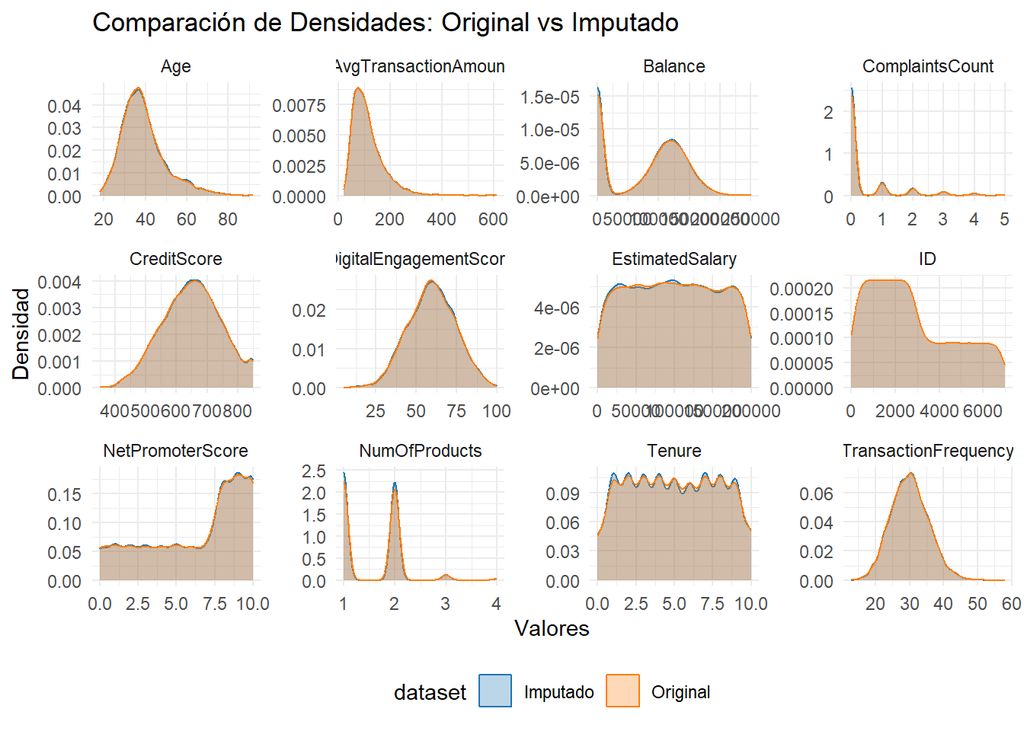

```r
density_before_after(data, datamice_final)
```

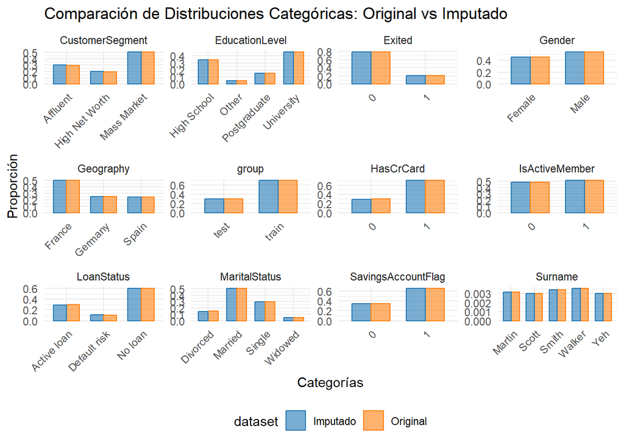

```r
mass_before_after(data, datamice_final)
```

Los resultados son muy buenos tanto para las variables numéricas como para las categóricas: las distribuciones se mantienen muy fieles a las existentes antes de la imputación. Además, todos los NA han sido removidos (solamente quedan los de las variables Surname e ID, que no se pueden imputar y no tienen valor predictivo, además de Exited para el grupo test).

Así pues, guardamos la base de datos final

```r
data_imputado<-datamice_final
rm(list = setdiff(ls(), "data_imputado"))
save(data_imputado, file = "data_imputado.RData")
```